# Risk Factor Analysis

## Outcome Variable

**Outcome Variable:** ever_swasted

## Predictor Variables

**Intervention Variable:** exclfeed6

**Adjustment Set:**

- arm
- sex
- brthmon
- W_mage
- meducyrs
- feducyrs
- hhwealth_quart
- hfoodsec
- W_mhtcm
- W_mwtkg
- W_mbmi
- vagbrth
- W_gagebrth
- W_birthwt
- W_birthlen
- W_nrooms
- W_nchldlt5
- month
- W_parity
- impfloor
- impsan
- safeh20
- delta_W_mage
- delta_meducyrs
- delta_feducyrs
- delta_hhwealth_quart
- delta_hfoodsec
- delta_W_mhtcm
- delta_W_mwtkg
- delta_W_mbmi
- delta_vagbrth
- delta_W_gagebrth
- delta_W_birthwt
- delta_W_birthlen
- delta_W_nrooms
- delta_W_nchldlt5
- delta_month
- delta_W_parity
- delta_impfloor
- delta_impsan
- delta_safeh20

## Stratifying Variables

The analysis was stratified on these variable(s):

- agecat
- studyid
- country

## Data Summary

| agecat | studyid | country | exclfeed6 | ever_swasted | n_cell | n |
| --- | --- | --- | --- | --- | --- | --- |
| 0-24 months (no birth wast) | CMC-V-BCS-2002 | INDIA | 1 | 0 | 15 | 19 |
| 0-24 months (no birth wast) | CMC-V-BCS-2002 | INDIA | 1 | 1 | 4 | 19 |
| 0-24 months (no birth wast) | CMC-V-BCS-2002 | INDIA | 0 | 0 | 0 | 19 |
| 0-24 months (no birth wast) | CMC-V-BCS-2002 | INDIA | 0 | 1 | 0 | 19 |
| 0-24 months (no birth wast) | EE | PAKISTAN | 1 | 0 | 38 | 48 |
| 0-24 months (no birth wast) | EE | PAKISTAN | 1 | 1 | 5 | 48 |
| 0-24 months (no birth wast) | EE | PAKISTAN | 0 | 0 | 4 | 48 |
| 0-24 months (no birth wast) | EE | PAKISTAN | 0 | 1 | 1 | 48 |
| 0-24 months (no birth wast) | GMS-Nepal | NEPAL | 1 | 0 | 330 | 560 |
| 0-24 months (no birth wast) | GMS-Nepal | NEPAL | 1 | 1 | 87 | 560 |
| 0-24 months (no birth wast) | GMS-Nepal | NEPAL | 0 | 0 | 104 | 560 |
| 0-24 months (no birth wast) | GMS-Nepal | NEPAL | 0 | 1 | 39 | 560 |
| 0-24 months (no birth wast) | IRC | INDIA | 1 | 0 | 0 | 14 |
| 0-24 months (no birth wast) | IRC | INDIA | 1 | 1 | 0 | 14 |
| 0-24 months (no birth wast) | IRC | INDIA | 0 | 0 | 9 | 14 |
| 0-24 months (no birth wast) | IRC | INDIA | 0 | 1 | 5 | 14 |
| 0-24 months (no birth wast) | JiVitA-3 | BANGLADESH | 1 | 0 | 11752 | 15666 |
| 0-24 months (no birth wast) | JiVitA-3 | BANGLADESH | 1 | 1 | 433 | 15666 |
| 0-24 months (no birth wast) | JiVitA-3 | BANGLADESH | 0 | 0 | 3358 | 15666 |
| 0-24 months (no birth wast) | JiVitA-3 | BANGLADESH | 0 | 1 | 123 | 15666 |
| 0-24 months (no birth wast) | JiVitA-4 | BANGLADESH | 1 | 0 | 3519 | 4722 |
| 0-24 months (no birth wast) | JiVitA-4 | BANGLADESH | 1 | 1 | 147 | 4722 |
| 0-24 months (no birth wast) | JiVitA-4 | BANGLADESH | 0 | 0 | 1005 | 4722 |
| 0-24 months (no birth wast) | JiVitA-4 | BANGLADESH | 0 | 1 | 51 | 4722 |
| 0-24 months (no birth wast) | Keneba | GAMBIA | 1 | 0 | 722 | 2226 |
| 0-24 months (no birth wast) | Keneba | GAMBIA | 1 | 1 | 101 | 2226 |
| 0-24 months (no birth wast) | Keneba | GAMBIA | 0 | 0 | 1159 | 2226 |
| 0-24 months (no birth wast) | Keneba | GAMBIA | 0 | 1 | 244 | 2226 |
| 0-24 months (no birth wast) | LCNI-5 | MALAWI | 1 | 0 | 47 | 271 |
| 0-24 months (no birth wast) | LCNI-5 | MALAWI | 1 | 1 | 0 | 271 |

[output cut: 186 more lines]

The following strata were considered:

- agecat: 0-24 months (no birth wast), studyid: CMC-V-BCS-2002, country: INDIA
- agecat: 0-24 months (no birth wast), studyid: EE, country: PAKISTAN
- agecat: 0-24 months (no birth wast), studyid: GMS-Nepal, country: NEPAL
- agecat: 0-24 months (no birth wast), studyid: IRC, country: INDIA
- agecat: 0-24 months (no birth wast), studyid: JiVitA-3, country: BANGLADESH
- agecat: 0-24 months (no birth wast), studyid: JiVitA-4, country: BANGLADESH
- agecat: 0-24 months (no birth wast), studyid: Keneba, country: GAMBIA
- agecat: 0-24 months (no birth wast), studyid: LCNI-5, country: MALAWI
- agecat: 0-24 months (no birth wast), studyid: MAL-ED, country: BANGLADESH
- agecat: 0-24 months (no birth wast), studyid: MAL-ED, country: BRAZIL
- agecat: 0-24 months (no birth wast), studyid: MAL-ED, country: INDIA
- agecat: 0-24 months (no birth wast), studyid: MAL-ED, country: NEPAL
- agecat: 0-24 months (no birth wast), studyid: MAL-ED, country: PERU
- agecat: 0-24 months (no birth wast), studyid: MAL-ED, country: SOUTH AFRICA
- agecat: 0-24 months (no birth wast), studyid: MAL-ED, country: TANZANIA, UNITED REPUBLIC OF
- agecat: 0-24 months (no birth wast), studyid: PROVIDE, country: BANGLADESH
- agecat: 0-24 months (no birth wast), studyid: SAS-CompFeed, country: INDIA
- agecat: 0-24 months (no birth wast), studyid: SAS-FoodSuppl, country: INDIA
- agecat: 0-6 months (no birth wast), studyid: CMC-V-BCS-2002, country: INDIA
- agecat: 0-6 months (no birth wast), studyid: EE, country: PAKISTAN
- agecat: 0-6 months (no birth wast), studyid: GMS-Nepal, country: NEPAL
- agecat: 0-6 months (no birth wast), studyid: IRC, country: INDIA
- agecat: 0-6 months (no birth wast), studyid: JiVitA-3, country: BANGLADESH
- agecat: 0-6 months (no birth wast), studyid: JiVitA-4, country: BANGLADESH
- agecat: 0-6 months (no birth wast), studyid: Keneba, country: GAMBIA
- agecat: 0-6 months (no birth wast), studyid: LCNI-5, country: MALAWI
- agecat: 0-6 months (no birth wast), studyid: MAL-ED, country: BANGLADESH
- agecat: 0-6 months (no birth wast), studyid: MAL-ED, country: BRAZIL
- agecat: 0-6 months (no birth wast), studyid: MAL-ED, country: INDIA
- agecat: 0-6 months (no birth wast), studyid: MAL-ED, country: NEPAL
- agecat: 0-6 months (no birth wast), studyid: MAL-ED, country: PERU
- agecat: 0-6 months (no birth wast), studyid: MAL-ED, country: SOUTH AFRICA
- agecat: 0-6 months (no birth wast), studyid: MAL-ED, country: TANZANIA, UNITED REPUBLIC OF
- agecat: 0-6 months (no birth wast), studyid: PROVIDE, country: BANGLADESH
- agecat: 0-6 months (no birth wast), studyid: SAS-CompFeed, country: INDIA
- agecat: 0-6 months (no birth wast), studyid: SAS-FoodSuppl, country: INDIA
- agecat: 6-24 months, studyid: CMC-V-BCS-2002, country: INDIA
- agecat: 6-24 months, studyid: EE, country: PAKISTAN
- agecat: 6-24 months, studyid: GMS-Nepal, country: NEPAL
- agecat: 6-24 months, studyid: IRC, country: INDIA
- agecat: 6-24 months, studyid: JiVitA-3, country: BANGLADESH
- agecat: 6-24 months, studyid: JiVitA-4, country: BANGLADESH
- agecat: 6-24 months, studyid: Keneba, country: GAMBIA
- agecat: 6-24 months, studyid: LCNI-5, country: MALAWI
- agecat: 6-24 months, studyid: MAL-ED, country: BANGLADESH
- agecat: 6-24 months, studyid: MAL-ED, country: BRAZIL
- agecat: 6-24 months, studyid: MAL-ED, country: INDIA
- agecat: 6-24 months, studyid: MAL-ED, country: NEPAL
- agecat: 6-24 months, studyid: MAL-ED, country: PERU
- agecat: 6-24 months, studyid: MAL-ED, country: SOUTH AFRICA
- agecat: 6-24 months, studyid: MAL-ED, country: TANZANIA, UNITED REPUBLIC OF
- agecat: 6-24 months, studyid: PROVIDE, country: BANGLADESH
- agecat: 6-24 months, studyid: SAS-CompFeed, country: INDIA
- agecat: 6-24 months, studyid: SAS-FoodSuppl, country: INDIA

### Dropped Strata

Some strata were dropped due to rare outcomes:

- agecat: 0-24 months (no birth wast), studyid: CMC-V-BCS-2002, country: INDIA
- agecat: 0-24 months (no birth wast), studyid: EE, country: PAKISTAN
- agecat: 0-24 months (no birth wast), studyid: IRC, country: INDIA
- agecat: 0-24 months (no birth wast), studyid: LCNI-5, country: MALAWI
- agecat: 0-24 months (no birth wast), studyid: MAL-ED, country: BANGLADESH
- agecat: 0-24 months (no birth wast), studyid: MAL-ED, country: BRAZIL
- agecat: 0-24 months (no birth wast), studyid: MAL-ED, country: INDIA
- agecat: 0-24 months (no birth wast), studyid: MAL-ED, country: NEPAL
- agecat: 0-24 months (no birth wast), studyid: MAL-ED, country: PERU
- agecat: 0-24 months (no birth wast), studyid: MAL-ED, country: SOUTH AFRICA
- agecat: 0-24 months (no birth wast), studyid: MAL-ED, country: TANZANIA, UNITED REPUBLIC OF
- agecat: 0-24 months (no birth wast), studyid: PROVIDE, country: BANGLADESH
- agecat: 0-24 months (no birth wast), studyid: SAS-CompFeed, country: INDIA
- agecat: 0-24 months (no birth wast), studyid: SAS-FoodSuppl, country: INDIA
- agecat: 0-6 months (no birth wast), studyid: CMC-V-BCS-2002, country: INDIA
- agecat: 0-6 months (no birth wast), studyid: EE, country: PAKISTAN
- agecat: 0-6 months (no birth wast), studyid: IRC, country: INDIA
- agecat: 0-6 months (no birth wast), studyid: LCNI-5, country: MALAWI
- agecat: 0-6 months (no birth wast), studyid: MAL-ED, country: BANGLADESH
- agecat: 0-6 months (no birth wast), studyid: MAL-ED, country: BRAZIL
- agecat: 0-6 months (no birth wast), studyid: MAL-ED, country: INDIA
- agecat: 0-6 months (no birth wast), studyid: MAL-ED, country: NEPAL
- agecat: 0-6 months (no birth wast), studyid: MAL-ED, country: PERU
- agecat: 0-6 months (no birth wast), studyid: MAL-ED, country: SOUTH AFRICA
- agecat: 0-6 months (no birth wast), studyid: MAL-ED, country: TANZANIA, UNITED REPUBLIC OF
- agecat: 0-6 months (no birth wast), studyid: PROVIDE, country: BANGLADESH
- agecat: 0-6 months (no birth wast), studyid: SAS-CompFeed, country: INDIA
- agecat: 0-6 months (no birth wast), studyid: SAS-FoodSuppl, country: INDIA
- agecat: 6-24 months, studyid: CMC-V-BCS-2002, country: INDIA
- agecat: 6-24 months, studyid: EE, country: PAKISTAN
- agecat: 6-24 months, studyid: IRC, country: INDIA
- agecat: 6-24 months, studyid: LCNI-5, country: MALAWI
- agecat: 6-24 months, studyid: MAL-ED, country: BANGLADESH
- agecat: 6-24 months, studyid: MAL-ED, country: BRAZIL
- agecat: 6-24 months, studyid: MAL-ED, country: INDIA
- agecat: 6-24 months, studyid: MAL-ED, country: NEPAL
- agecat: 6-24 months, studyid: MAL-ED, country: PERU
- agecat: 6-24 months, studyid: MAL-ED, country: SOUTH AFRICA
- agecat: 6-24 months, studyid: MAL-ED, country: TANZANIA, UNITED REPUBLIC OF
- agecat: 6-24 months, studyid: PROVIDE, country: BANGLADESH
- agecat: 6-24 months, studyid: SAS-CompFeed, country: INDIA
- agecat: 6-24 months, studyid: SAS-FoodSuppl, country: INDIA

## Methods Detail

We’re interested in the causal parameters $E[Y_a]$ for all values of $a \in \mathcal{A}$. These parameters represent the mean outcome if, possibly contrary to fact, we intervened to set all units to have $A=a$. Under the randomization and positivity assumptions, these are identified by the statistical parameters $\psi_a=E_W[E_{Y|A,W}(Y|A=a,W)]$. In addition, we’re interested in the mean of $Y$, $E[Y]$ under no intervention (the observed mean). We will estimate these parameters by using SuperLearner to fit the relevant likelihood factors – $E_{Y|A,W}(Y|A=a,W)$ and $p(A=a|W)$, and then updating our likelihood fit using a joint TMLE.

For unadjusted analyses ($W=\{\}$), initial likelihoods were estimated using Lrnr_glm to estimate the simple $E(Y|A)$ and Lrnr_mean to estimate $p(A)$. For adjusted analyses, a small library containing Lrnr_glmnet, Lrnr_xgboost, and Lrnr_mean was used.

Having estimated these parameters, we will then use the delta method to estimate relative risks and attributable risks relative to a prespecified baseline level of $A$.

# Results Detail

## Results Plots

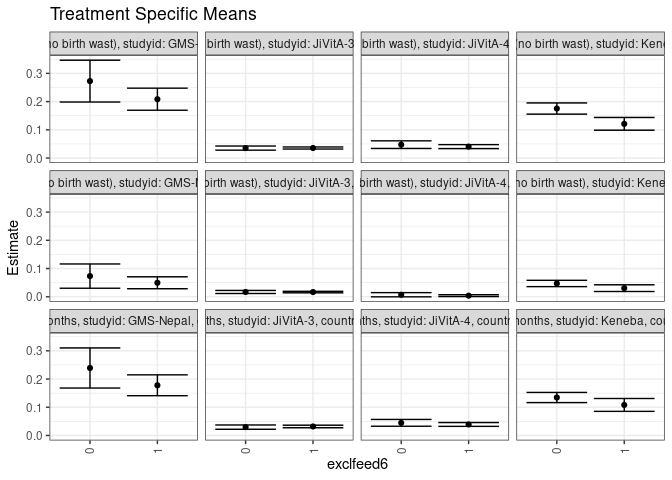

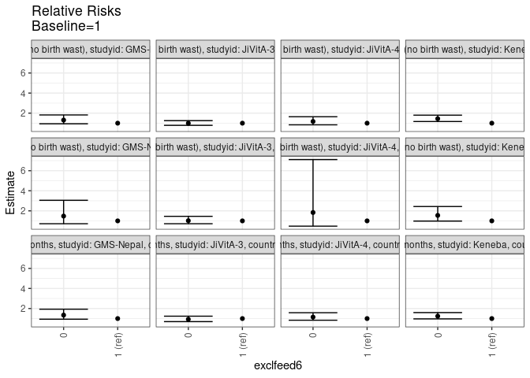

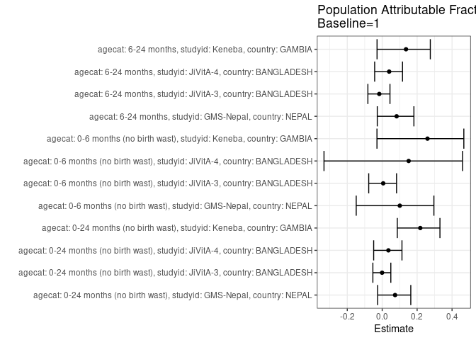

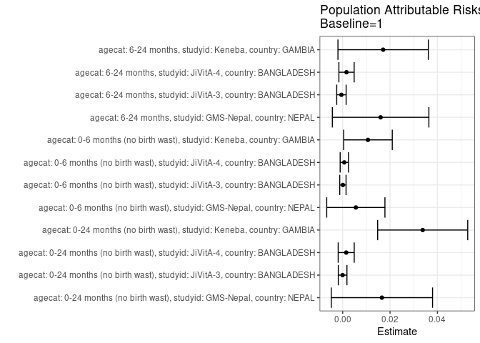

## Results Table

### Parameter: TSM

| agecat | studyid | country | intervention_level | baseline_level | estimate | ci_lower | ci_upper |
| --- | --- | --- | --- | --- | --- | --- | --- |
| 0-24 months (no birth wast) | GMS-Nepal | NEPAL | 1 | NA | 0.2084365 | 0.1693100 | 0.2475631 |
| 0-24 months (no birth wast) | GMS-Nepal | NEPAL | 0 | NA | 0.2725763 | 0.1984648 | 0.3466878 |
| 0-24 months (no birth wast) | JiVitA-3 | BANGLADESH | 1 | NA | 0.0355163 | 0.0318740 | 0.0391585 |
| 0-24 months (no birth wast) | JiVitA-3 | BANGLADESH | 0 | NA | 0.0352457 | 0.0278849 | 0.0426065 |
| 0-24 months (no birth wast) | JiVitA-4 | BANGLADESH | 1 | NA | 0.0404405 | 0.0334600 | 0.0474209 |
| 0-24 months (no birth wast) | JiVitA-4 | BANGLADESH | 0 | NA | 0.0473901 | 0.0338778 | 0.0609023 |
| 0-24 months (no birth wast) | Keneba | GAMBIA | 1 | NA | 0.1211951 | 0.0986173 | 0.1437729 |
| 0-24 months (no birth wast) | Keneba | GAMBIA | 0 | NA | 0.1754342 | 0.1555864 | 0.1952821 |
| 0-6 months (no birth wast) | GMS-Nepal | NEPAL | 1 | NA | 0.0495931 | 0.0284582 | 0.0707281 |
| 0-6 months (no birth wast) | GMS-Nepal | NEPAL | 0 | NA | 0.0731993 | 0.0301813 | 0.1162173 |
| 0-6 months (no birth wast) | JiVitA-3 | BANGLADESH | 1 | NA | 0.0166433 | 0.0140180 | 0.0192685 |
| 0-6 months (no birth wast) | JiVitA-3 | BANGLADESH | 0 | NA | 0.0169499 | 0.0114702 | 0.0224296 |
| 0-6 months (no birth wast) | JiVitA-4 | BANGLADESH | 1 | NA | 0.0038792 | 0.0005950 | 0.0071633 |
| 0-6 months (no birth wast) | JiVitA-4 | BANGLADESH | 0 | NA | 0.0071138 | -0.0003332 | 0.0145609 |
| 0-6 months (no birth wast) | Keneba | GAMBIA | 1 | NA | 0.0304960 | 0.0186609 | 0.0423310 |
| 0-6 months (no birth wast) | Keneba | GAMBIA | 0 | NA | 0.0470809 | 0.0359081 | 0.0582537 |
| 6-24 months | GMS-Nepal | NEPAL | 1 | NA | 0.1778761 | 0.1409271 | 0.2148252 |
| 6-24 months | GMS-Nepal | NEPAL | 0 | NA | 0.2391457 | 0.1681169 | 0.3101745 |
| 6-24 months | JiVitA-3 | BANGLADESH | 1 | NA | 0.0318926 | 0.0273999 | 0.0363853 |
| 6-24 months | JiVitA-3 | BANGLADESH | 0 | NA | 0.0295948 | 0.0219941 | 0.0371955 |
| 6-24 months | JiVitA-4 | BANGLADESH | 1 | NA | 0.0390765 | 0.0322847 | 0.0458683 |
| 6-24 months | JiVitA-4 | BANGLADESH | 0 | NA | 0.0448401 | 0.0327909 | 0.0568894 |
| 6-24 months | Keneba | GAMBIA | 1 | NA | 0.1082685 | 0.0854402 | 0.1310968 |
| 6-24 months | Keneba | GAMBIA | 0 | NA | 0.1345294 | 0.1164768 | 0.1525821 |

### Parameter: E(Y)

| agecat | studyid | country | intervention_level | baseline_level | estimate | ci_lower | ci_upper |
| --- | --- | --- | --- | --- | --- | --- | --- |
| 0-24 months (no birth wast) | GMS-Nepal | NEPAL | NA | NA | 0.2250000 | 0.1903834 | 0.2596166 |
| 0-24 months (no birth wast) | JiVitA-3 | BANGLADESH | NA | NA | 0.0354909 | 0.0322227 | 0.0387591 |
| 0-24 months (no birth wast) | JiVitA-4 | BANGLADESH | NA | NA | 0.0419314 | 0.0358274 | 0.0480353 |
| 0-24 months (no birth wast) | Keneba | GAMBIA | NA | NA | 0.1549865 | 0.1399495 | 0.1700235 |
| 0-6 months (no birth wast) | GMS-Nepal | NEPAL | NA | NA | 0.0551471 | 0.0359475 | 0.0743466 |
| 0-6 months (no birth wast) | JiVitA-3 | BANGLADESH | NA | NA | 0.0167386 | 0.0143298 | 0.0191473 |
| 0-6 months (no birth wast) | JiVitA-4 | BANGLADESH | NA | NA | 0.0045722 | 0.0015532 | 0.0075911 |
| 0-6 months (no birth wast) | Keneba | GAMBIA | NA | NA | 0.0411765 | 0.0328905 | 0.0494625 |
| 6-24 months | GMS-Nepal | NEPAL | NA | NA | 0.1938959 | 0.1610341 | 0.2267576 |
| 6-24 months | JiVitA-3 | BANGLADESH | NA | NA | 0.0313664 | 0.0274269 | 0.0353059 |
| 6-24 months | JiVitA-4 | BANGLADESH | NA | NA | 0.0407001 | 0.0348212 | 0.0465791 |
| 6-24 months | Keneba | GAMBIA | NA | NA | 0.1253589 | 0.1111594 | 0.1395583 |

### Parameter: RR

| agecat | studyid | country | intervention_level | baseline_level | estimate | ci_lower | ci_upper |
| --- | --- | --- | --- | --- | --- | --- | --- |
| 0-24 months (no birth wast) | GMS-Nepal | NEPAL | 1 | 1 | 1.0000000 | 1.0000000 | 1.000000 |
| 0-24 months (no birth wast) | GMS-Nepal | NEPAL | 0 | 1 | 1.3077184 | 0.9393456 | 1.820552 |
| 0-24 months (no birth wast) | JiVitA-3 | BANGLADESH | 1 | 1 | 1.0000000 | 1.0000000 | 1.000000 |
| 0-24 months (no birth wast) | JiVitA-3 | BANGLADESH | 0 | 1 | 0.9923830 | 0.7862816 | 1.252508 |
| 0-24 months (no birth wast) | JiVitA-4 | BANGLADESH | 1 | 1 | 1.0000000 | 1.0000000 | 1.000000 |
| 0-24 months (no birth wast) | JiVitA-4 | BANGLADESH | 0 | 1 | 1.1718478 | 0.8366877 | 1.641266 |
| 0-24 months (no birth wast) | Keneba | GAMBIA | 1 | 1 | 1.0000000 | 1.0000000 | 1.000000 |
| 0-24 months (no birth wast) | Keneba | GAMBIA | 0 | 1 | 1.4475359 | 1.1649386 | 1.798687 |
| 0-6 months (no birth wast) | GMS-Nepal | NEPAL | 1 | 1 | 1.0000000 | 1.0000000 | 1.000000 |
| 0-6 months (no birth wast) | GMS-Nepal | NEPAL | 0 | 1 | 1.4759963 | 0.7141197 | 3.050700 |
| 0-6 months (no birth wast) | JiVitA-3 | BANGLADESH | 1 | 1 | 1.0000000 | 1.0000000 | 1.000000 |
| 0-6 months (no birth wast) | JiVitA-3 | BANGLADESH | 0 | 1 | 1.0184243 | 0.7137898 | 1.453072 |
| 0-6 months (no birth wast) | JiVitA-4 | BANGLADESH | 1 | 1 | 1.0000000 | 1.0000000 | 1.000000 |
| 0-6 months (no birth wast) | JiVitA-4 | BANGLADESH | 0 | 1 | 1.8338413 | 0.4728250 | 7.112513 |
| 0-6 months (no birth wast) | Keneba | GAMBIA | 1 | 1 | 1.0000000 | 1.0000000 | 1.000000 |
| 0-6 months (no birth wast) | Keneba | GAMBIA | 0 | 1 | 1.5438407 | 0.9796722 | 2.432900 |
| 6-24 months | GMS-Nepal | NEPAL | 1 | 1 | 1.0000000 | 1.0000000 | 1.000000 |
| 6-24 months | GMS-Nepal | NEPAL | 0 | 1 | 1.3444507 | 0.9356880 | 1.931785 |
| 6-24 months | JiVitA-3 | BANGLADESH | 1 | 1 | 1.0000000 | 1.0000000 | 1.000000 |
| 6-24 months | JiVitA-3 | BANGLADESH | 0 | 1 | 0.9279539 | 0.6958124 | 1.237544 |
| 6-24 months | JiVitA-4 | BANGLADESH | 1 | 1 | 1.0000000 | 1.0000000 | 1.000000 |
| 6-24 months | JiVitA-4 | BANGLADESH | 0 | 1 | 1.1474955 | 0.8326280 | 1.581434 |
| 6-24 months | Keneba | GAMBIA | 1 | 1 | 1.0000000 | 1.0000000 | 1.000000 |
| 6-24 months | Keneba | GAMBIA | 0 | 1 | 1.2425535 | 0.9681279 | 1.594768 |

### Parameter: PAR

| agecat | studyid | country | intervention_level | baseline_level | estimate | ci_lower | ci_upper |
| --- | --- | --- | --- | --- | --- | --- | --- |
| 0-24 months (no birth wast) | GMS-Nepal | NEPAL | 1 | NA | 0.0165635 | -0.0048253 | 0.0379522 |
| 0-24 months (no birth wast) | JiVitA-3 | BANGLADESH | 1 | NA | -0.0000254 | -0.0018485 | 0.0017977 |
| 0-24 months (no birth wast) | JiVitA-4 | BANGLADESH | 1 | NA | 0.0014909 | -0.0018950 | 0.0048768 |
| 0-24 months (no birth wast) | Keneba | GAMBIA | 1 | NA | 0.0337914 | 0.0147752 | 0.0528077 |
| 0-6 months (no birth wast) | GMS-Nepal | NEPAL | 1 | NA | 0.0055539 | -0.0067388 | 0.0178466 |
| 0-6 months (no birth wast) | JiVitA-3 | BANGLADESH | 1 | NA | 0.0000953 | -0.0012386 | 0.0014292 |
| 0-6 months (no birth wast) | JiVitA-4 | BANGLADESH | 1 | NA | 0.0006930 | -0.0010617 | 0.0024476 |
| 0-6 months (no birth wast) | Keneba | GAMBIA | 1 | NA | 0.0106805 | 0.0004168 | 0.0209442 |
| 6-24 months | GMS-Nepal | NEPAL | 1 | NA | 0.0160197 | -0.0043597 | 0.0363991 |
| 6-24 months | JiVitA-3 | BANGLADESH | 1 | NA | -0.0005262 | -0.0025107 | 0.0014583 |
| 6-24 months | JiVitA-4 | BANGLADESH | 1 | NA | 0.0016236 | -0.0016008 | 0.0048480 |
| 6-24 months | Keneba | GAMBIA | 1 | NA | 0.0170903 | -0.0019912 | 0.0361718 |

### Parameter: PAF

| agecat | studyid | country | intervention_level | baseline_level | estimate | ci_lower | ci_upper |
| --- | --- | --- | --- | --- | --- | --- | --- |
| 0-24 months (no birth wast) | GMS-Nepal | NEPAL | 1 | NA | 0.0736154 | -0.0261830 | 0.1637083 |
| 0-24 months (no birth wast) | JiVitA-3 | BANGLADESH | 1 | NA | -0.0007151 | -0.0534283 | 0.0493603 |
| 0-24 months (no birth wast) | JiVitA-4 | BANGLADESH | 1 | NA | 0.0355562 | -0.0488494 | 0.1131693 |
| 0-24 months (no birth wast) | Keneba | GAMBIA | 1 | NA | 0.2180282 | 0.0864278 | 0.3306715 |
| 0-6 months (no birth wast) | GMS-Nepal | NEPAL | 1 | NA | 0.1007111 | -0.1488200 | 0.2960424 |
| 0-6 months (no birth wast) | JiVitA-3 | BANGLADESH | 1 | NA | 0.0056933 | -0.0771861 | 0.0821959 |
| 0-6 months (no birth wast) | JiVitA-4 | BANGLADESH | 1 | NA | 0.1515655 | -0.3333170 | 0.4601126 |
| 0-6 months (no birth wast) | Keneba | GAMBIA | 1 | NA | 0.2593839 | -0.0299779 | 0.4674525 |
| 6-24 months | GMS-Nepal | NEPAL | 1 | NA | 0.0826202 | -0.0282636 | 0.1815468 |
| 6-24 months | JiVitA-3 | BANGLADESH | 1 | NA | -0.0167755 | -0.0819858 | 0.0445046 |
| 6-24 months | JiVitA-4 | BANGLADESH | 1 | NA | 0.0398916 | -0.0431119 | 0.1162903 |
| 6-24 months | Keneba | GAMBIA | 1 | NA | 0.1363313 | -0.0295388 | 0.2754778 |